### Importación de datos

```python
import pandas as pd

url = "https://raw.githubusercontent.com/alura-es-cursos/challenge1-data-science-latam/refs/heads/main/base-de-datos-challenge1-latam/tienda_1%20.csv"
url2 = "https://raw.githubusercontent.com/alura-es-cursos/challenge1-data-science-latam/refs/heads/main/base-de-datos-challenge1-latam/tienda_2.csv"
url3 = "https://raw.githubusercontent.com/alura-es-cursos/challenge1-data-science-latam/refs/heads/main/base-de-datos-challenge1-latam/tienda_3.csv"
url4 = "https://raw.githubusercontent.com/alura-es-cursos/challenge1-data-science-latam/refs/heads/main/base-de-datos-challenge1-latam/tienda_4.csv"

tienda = pd.read_csv(url)
tienda2 = pd.read_csv(url2)
tienda3 = pd.read_csv(url3)
tienda4 = pd.read_csv(url4)

tienda.head()
```

|  | Producto | Categoría del Producto | Precio | Costo de envío | Fecha de Compra | Vendedor | Lugar de Compra | Calificación | Método de pago | Cantidad de cuotas | lat | lon |
| --- | --- | --- | --- | --- | --- | --- | --- | --- | --- | --- | --- | --- |
| 0 | Asistente virtual | Electrónicos | 164300.0 | 6900.0 | 16/01/2021 | Pedro Gomez | Bogotá | 4 | Tarjeta de crédito | 8 | 4.60971 | -74.08175 |
| 1 | Mesa de comedor | Muebles | 192300.0 | 8400.0 | 18/05/2022 | Beatriz Morales | Medellín | 1 | Tarjeta de crédito | 4 | 6.25184 | -75.56359 |
| 2 | Juego de mesa | Juguetes | 209600.0 | 15900.0 | 15/03/2021 | Juan Fernandez | Cartagena | 1 | Tarjeta de crédito | 1 | 10.39972 | -75.51444 |
| 3 | Microondas | Electrodomésticos | 757500.0 | 41000.0 | 03/05/2022 | Juan Fernandez | Cali | 4 | Nequi | 1 | 3.43722 | -76.52250 |
| 4 | Silla de oficina | Muebles | 335200.0 | 20200.0 | 07/11/2020 | Maria Alfonso | Medellín | 5 | Nequi | 1 | 6.25184 | -75.56359 |

# 1. Análisis de facturación

```python
#Biblioteca para docstring
from typing import List, Optional, Tuple, Dict, Any
```

```python
def agrupa_valor_tabla(
    lista1: Optional[List[float]] = None,
    lista2: Optional[List[float]] = None,
    lista3: Optional[List[float]] = None,
    lista4: Optional[List[float]] = None
) -> List[float]:
    """
    Suma los elementos de hasta cuatro listas numéricas y devuelve los resultados individuales.

    Parámetros:
    ----------
    lista1 : Optional[List[float]], opcional
        Primera lista de números. Por defecto None.
    lista2 : Optional[List[float]], opcional
        Segunda lista de números. Por defecto None.
    lista3 : Optional[List[float]], opcional
        Tercera lista de números. Por defecto None.
    lista4 : Optional[List[float]], opcional
        Cuarta lista de números. Por defecto None.

    Retorna:
    -------
    List[float]
        Lista con la suma de cada lista individual (en orden).
    """
    resultados = []

    for lista in (lista1, lista2, lista3, lista4):
        if lista is not None:
            resultados.append(sum(lista))
        else:
            resultados.append(0.0)

    return resultados

ingreso_tienda = agrupa_valor_tabla(tienda['Precio'], tienda2['Precio'], tienda3['Precio'], tienda4['Precio'])
ingreso_total = sum(ingreso_tienda)
print(f'El ingreso total de la empresa es: {ingreso_total}')
```

```
El ingreso total de la empresa es: 4403619200.0
```

# 2. Ventas por categoría

```python
def agrupa_columna_tabla(
    lista1: Optional[List] = None,
    lista2: Optional[List] = None,
    lista3: Optional[List] = None
) -> List[Tuple]:
    """
    Agrupa dinámicamente elementos de las listas proporcionadas en una lista de tuplas.

    Solo se agrupan aquellas listas que se pasen explícitamente como argumento.
    Las listas deben tener la misma longitud para evitar pérdida de datos, ya que se recortan
    al tamaño de la más corta (comportamiento de zip).

    Parámetros:
    ----------
    lista1 : Optional[List], opcional
        Primera columna de datos. Por defecto None.
    lista2 : Optional[List], opcional
        Segunda columna de datos. Por defecto None.
    lista3 : Optional[List], opcional
        Tercera columna de datos. Por defecto None.

    Retorna:
    -------
    List[Tuple]
        Lista de tuplas, donde cada tupla representa una fila con los elementos agrupados
        de las listas proporcionadas.
    """
    columnas: List[List] = []

    if lista1 is not None:
        columnas.append(lista1)
    if lista2 is not None:
        columnas.append(lista2)
    if lista3 is not None:
        columnas.append(lista3)

    return list(zip(*columnas)) if columnas else []

def obtiene_categoria(lista: Optional[List[Any]] = None) -> List[Any]:
    """
    Devuelve una lista con los elementos únicos de la lista proporcionada.

    Parámetros:
    ----------
    lista : Optional[List[Any]], opcional
        Lista de elementos (cualquier tipo). Si no se proporciona, se usa una lista vacía.

    Retorna:
    -------
    List[Any]
        Lista con los elementos únicos (sin repeticiones) de la lista original.
    """
    if lista is None:
        lista = []
    return list(set(lista))

def suma_venta_producto_categoria(
    lista1: Optional[List[str]] = None,
    lista2: Optional[List[Tuple[str, int]]] = None
) -> Dict[str, int]:
    """
    Crea un diccionario y suma los elementos de una lista de tuplas según las claves presentes en lista1.

    Parámetros:
    ----------
    lista1 : Optional[List[str]], opcional
        Lista de claves (categorías) como strings. Por defecto None.
    lista2 : Optional[List[Tuple[str, int]]], opcional
        Lista de tuplas con pares (categoría, valor). Por defecto None.

    Retorna:
    -------
    Dict[str, int]
        Diccionario con cada categoría de lista1 como clave y la suma de los valores asociados
        en lista2. El diccionario resultante está ordenado de forma descendente por valor.
    """
    if lista1 is None:
        lista1 = []
    if lista2 is None:
        lista2 = []

    diccionario = {
        lista1[e]: sum([valor[1] for valor in lista2 if valor[0] == lista1[e]])
        for e in range(len(lista1))
    }

    return dict(sorted(diccionario.items(), key=lambda x: x[1], reverse=True))

#Lista de tiendas del negocio
negocio = ['tienda 1','tienda 2','tienda 3','tienda 4']

#Extrae las categorías del negocio
negocio_categoria = sorted(obtiene_categoria(tienda['Categoría del Producto']), reverse=True)

#Categorias y cantidad de ventas de cada producto en cada tienda
venta_categoria_t = agrupa_columna_tabla(tienda['Categoría del Producto'],tienda['Cantidad de cuotas'])
venta_categoria_t2 = agrupa_columna_tabla(tienda2['Categoría del Producto'],tienda2['Cantidad de cuotas'])
venta_categoria_t3 = agrupa_columna_tabla(tienda3['Categoría del Producto'],tienda3['Cantidad de cuotas'])
venta_categoria_t4 = agrupa_columna_tabla(tienda4['Categoría del Producto'],tienda4['Cantidad de cuotas'])

#Categorías más populares de cada tienda
categoria_popular = suma_venta_producto_categoria(negocio_categoria,venta_categoria_t)
categoria_popular2 = suma_venta_producto_categoria(negocio_categoria,venta_categoria_t2)
categoria_popular3 = suma_venta_producto_categoria(negocio_categoria,venta_categoria_t3)
categoria_popular4 = suma_venta_producto_categoria(negocio_categoria,venta_categoria_t4)

mas_vendido_t = max(categoria_popular, key=categoria_popular.get)
mas_vendido_t2 = max(categoria_popular2, key=categoria_popular2.get)
mas_vendido_t3 = max(categoria_popular3, key=categoria_popular3.get)
mas_vendido_t4 = max(categoria_popular4, key=categoria_popular4.get)

print(f'La categoría más popular de la tienda 1 es: {mas_vendido_t} y la cantidad vendida fue: {categoria_popular[mas_vendido_t]}')
print(f'La categoría más popular de la tienda 2 es: {mas_vendido_t2} y la cantidad vendida fue: {categoria_popular2[mas_vendido_t2]}')
print(f'La categoría más popular de la tienda 3 es: {mas_vendido_t3} y la cantidad vendida fue: {categoria_popular3[mas_vendido_t3]}')
print(f'La categoría más popular de la tienda 4 es: {mas_vendido_t4} y la cantidad vendida fue: {categoria_popular4[mas_vendido_t4]}')
```

```
La categoría más popular de la tienda 1 es: Muebles y la cantidad vendida fue: 1446
La categoría más popular de la tienda 2 es: Electrónicos y la cantidad vendida fue: 1333
La categoría más popular de la tienda 3 es: Muebles y la cantidad vendida fue: 1408
La categoría más popular de la tienda 4 es: Muebles y la cantidad vendida fue: 1392
```

# 3. Calificación promedio de la tienda

```python
def promedio(lista: List[float] = None) -> float:
    """
    Calcula el promedio de una lista de números.

    Parámetros:
    ----------
    lista : List[float]
        Lista de valores numéricos. Por defecto None.

    Retorna:
    -------
    float
        Promedio redondeado a 4 decimales. Si la lista está vacía o es None, retorna 0.0.
    """
    if lista is None:
      return 0.0
    return round(sum(lista) / len(lista), 4)

promedio_tienda = promedio(tienda['Calificación'])
promedio_tienda2 = promedio(tienda2['Calificación'])
promedio_tienda3 = promedio(tienda3['Calificación'])
promedio_tienda4 = promedio(tienda4['Calificación'])

print(f'La tienda 1 tiene: {promedio_tienda} de valoración')
print(f'La tienda 2 tiene: {promedio_tienda2} de valoración')
print(f'La tienda 3 tiene: {promedio_tienda3} de valoración')
print(f'La tienda 4 tiene: {promedio_tienda4} de valoración')
```

```
La tienda 1 tiene: 3.9767 de valoración
La tienda 2 tiene: 4.0373 de valoración
La tienda 3 tiene: 4.0483 de valoración
La tienda 4 tiene: 3.9958 de valoración
```

# 4. Productos más y menos vendidos

```python
def muestra_venta(
    no_tienda: int = 0,
    diccionario: Optional[Dict[str, int]] = None,
    cantidad: int = 1,
    mas_vendido: bool = True
) -> None:
    """
    Muestra los productos más o menos vendidos de una tienda.

    Parámetros:
    ----------
    no_tienda : int
        Número de la tienda (por defecto 0).
    diccionario : dict[str, int]
        Diccionario con productos como claves y ventas como valores. Por defecto None.
    cantidad : int, opcional
        Número de productos a mostrar (por defecto 1).
    mas_vendido : bool, opcional
        Si True muestra los más vendidos, si False los menos vendidos (por defecto True).
    """
    if diccionario is None or not diccionario:
        print(f"No hay datos de venta disponibles para la tienda {no_tienda}.")
        return

    claves = list(diccionario.keys())
    valores = list(diccionario.values())

    cantidad = min(cantidad, len(diccionario))  # Evita IndexError

    if mas_vendido:
        for e in range(cantidad):
            print(f"El producto No.{e + 1} más vendido de la tienda {no_tienda} es: {claves[e]} y la cantidad vendida fue: {valores[e]}")
    else:
        for e in range(1, cantidad + 1):
            print(f"El producto No.{e} menos vendido de la tienda {no_tienda} es: {claves[-e]} y la cantidad vendida fue: {valores[-e]}")

#Productos vendidos
producto_vendido = suma_venta_producto_categoria(obtiene_categoria(tienda['Producto']),agrupa_columna_tabla(tienda['Producto'],tienda['Cantidad de cuotas']))
producto_vendido2 = suma_venta_producto_categoria(obtiene_categoria(tienda2['Producto']),agrupa_columna_tabla(tienda2['Producto'],tienda2['Cantidad de cuotas']))
producto_vendido3 = suma_venta_producto_categoria(obtiene_categoria(tienda3['Producto']),agrupa_columna_tabla(tienda3['Producto'],tienda3['Cantidad de cuotas']))
producto_vendido4 = suma_venta_producto_categoria(obtiene_categoria(tienda4['Producto']),agrupa_columna_tabla(tienda4['Producto'],tienda4['Cantidad de cuotas']))

#Productos más vendidos
muestra_venta(1,producto_vendido,1, True)
muestra_venta(2,producto_vendido2,1, True)
muestra_venta(3,producto_vendido3,1, True)
muestra_venta(4,producto_vendido4,1, True)

#Productos menos vendidos
muestra_venta(1,producto_vendido,1, False)
muestra_venta(2,producto_vendido2,1, False)
muestra_venta(3,producto_vendido3,1, False)
muestra_venta(4,producto_vendido4,1, False)
```

```
El producto No.1 más vendido de la tienda 1 es: Secadora de ropa y la cantidad vendida fue: 214
El producto No.1 más vendido de la tienda 2 es: Iniciando en programación y la cantidad vendida fue: 223
El producto No.1 más vendido de la tienda 3 es: Bicicleta y la cantidad vendida fue: 191
El producto No.1 más vendido de la tienda 4 es: Dashboards con Power BI y la cantidad vendida fue: 196
El producto No.1 menos vendido de la tienda 1 es: Celular ABXY y la cantidad vendida fue: 78
El producto No.1 menos vendido de la tienda 2 es: Mesa de comedor y la cantidad vendida fue: 89
El producto No.1 menos vendido de la tienda 3 es: TV LED UHD 4K y la cantidad vendida fue: 94
El producto No.1 menos vendido de la tienda 4 es: Armario y la cantidad vendida fue: 88
```

# 5. Envío promedio por tienda

```python
costo_envio_t = promedio(tienda['Costo de envío'])
costo_envio_t2 = promedio(tienda2['Costo de envío'])
costo_envio_t3 = promedio(tienda3['Costo de envío'])
costo_envio_t4 = promedio(tienda4['Costo de envío'])

print(f'El costo de envío promedio de la tienda 1 es: {costo_envio_t}')
print(f'El costo de envío promedio de la tienda 2 es: {costo_envio_t2}')
print(f'El costo de envío promedio de la tienda 3 es: {costo_envio_t3}')
print(f'El costo de envío promedio de la tienda 4 es: {costo_envio_t4}')
```

```
El costo de envío promedio de la tienda 1 es: 26018.6096
El costo de envío promedio de la tienda 2 es: 25216.2357
El costo de envío promedio de la tienda 3 es: 24805.6804
El costo de envío promedio de la tienda 4 es: 23459.4572
```

# 6. Visualización

###### Gráfica 1. Ingresos por tienda

```python
#Blibliotecas para las gráficas
from matplotlib import pyplot as plt
from matplotlib import cm
from matplotlib import colors
from mpl_toolkits.mplot3d import Axes3D
import numpy as np
```

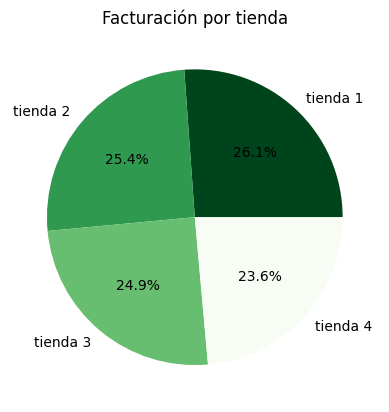

```python
normdata = colors.Normalize(min(ingreso_tienda), max(ingreso_tienda))
colores = [colors.rgb2hex(c) for c in cm.Greens(normdata(ingreso_tienda))]
plt.pie(ingreso_tienda, labels=negocio, autopct='%1.1f%%', colors=colores)
plt.title('Facturación por tienda')
plt.show()
```

##### Gráfica 2. Ventas por categoría

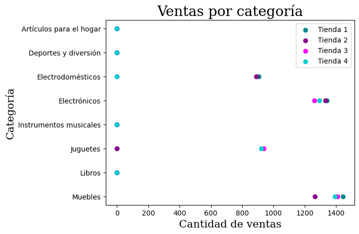

```python
def obtiene_eje_x(
    diccionario: Optional[Dict[str, int]] = None,
    lista: Optional[List[str]] = None,
    numero: int = 0
) -> List[int]:
    """
    Obtiene los valores de un diccionario según un orden dado y prepara una lista para graficar.

    Parámetros:
    ----------
    diccionario : dict[str, int], opcional
        Diccionario con categorías como claves y cantidades como valores.
    lista : list[str], opcional
        Lista que define el orden en el que se graficarán las categorías.
    numero : int, opcional
        Cantidad de categorías a mostrar con sus valores reales; el resto se rellena con ceros.

    Retorna:
    -------
    list[int]
        Lista de valores a graficar, ordenados según `lista`, con ceros donde no se desea mostrar el valor.
    """
    if diccionario is None:
        diccionario = {}
    if lista is None:
        lista = []

    eje_x = []

    for elemento in lista:
        if elemento in diccionario:
            # Obtener la posición del elemento en el diccionario original
            pos = list(diccionario.keys()).index(elemento)
            # Si está dentro del rango deseado, se agrega su valor; si no, se agrega 0
            valor = diccionario[elemento] if pos < numero else 0
            eje_x.append(valor)
        else:
            # Si el elemento no está en el diccionario, se asume como 0
            eje_x.append(0)

    return eje_x

#Cantidad de categorías a mostrar
no_categoria = 3

#Definir ejes a gráficar
x1 = obtiene_eje_x(categoria_popular,negocio_categoria,no_categoria)
x2 = obtiene_eje_x(categoria_popular2,negocio_categoria,no_categoria)
x3  = obtiene_eje_x(categoria_popular3,negocio_categoria,no_categoria)
x4 = obtiene_eje_x(categoria_popular4,negocio_categoria,no_categoria)
y = negocio_categoria

#Gráfica
g1 = plt.scatter(x1, y, color = '#008B8B', label = 'Tienda 1')
g2 = plt.scatter(x2, y, color = '#8B008B', label = 'Tienda 2')
g3 = plt.scatter(x3, y, color = '#FF00FF', label = 'Tienda 3')
g4 = plt.scatter(x4, y, color = '#00CED1', label = 'Tienda 4')

#Estilos etiquetas
font1 = {'family':'serif','color':'black','size':20}
font2 = {'family':'serif','color':'black','size':15}

#Etiquetas gráfica
plt.title('Ventas por categoría', fontdict = font1)
plt.xlabel('Cantidad de ventas', fontdict = font2)
plt.ylabel('Categoría', fontdict = font2)
plt.legend()

#Muestra gráfica
plt.show()
```

##### Gráfica 3. Satisfacción de clientes por tienda

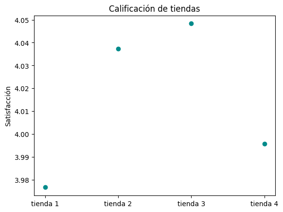

```python
#Calificación de las tiendas
satisfaccion_negocio = [promedio_tienda, promedio_tienda2, promedio_tienda3, promedio_tienda4]

#Gráfica de dispersión
plt.scatter(negocio, satisfaccion_negocio, color='#008B8B')

#Etiquetas
plt.ylabel('Satisfacción')
plt.title('Calificación de tiendas')

#Muestra gráfica
plt.show()
```

###### Gráfica 4. Productos más vendidos

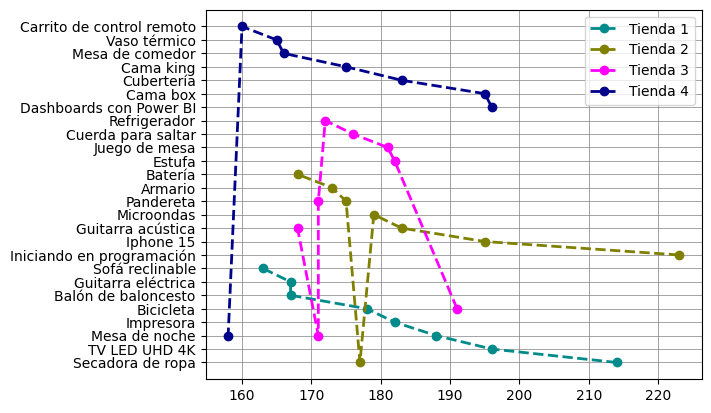

```python
def obtiene_ejes(
    diccionario: Optional[Dict[str, int]] = None,
    cantidad: int = 0,
    mas_vendido: bool = True
) -> Tuple[List[str], List[int]]:
    """
    Obtiene listas de claves y valores desde un diccionario ordenado, para graficar productos más o menos vendidos.

    Parámetros:
    ----------
    diccionario : dict[str, int], opcional
        Diccionario con productos como claves y cantidades vendidas como valores.
    cantidad : int, opcional
        Número de productos a mostrar (por defecto 0).
    mas_vendido : bool, opcional
        Si True muestra los más vendidos; si False, los menos vendidos (por defecto True).

    Retorna:
    -------
    tuple[list[str], list[int]]
        Dos listas: eje X con los nombres de productos y eje Y con las cantidades correspondientes.
    """
    if diccionario is None:
        diccionario = {}

    # Obtener lista de claves y valores según el orden
    claves = list(diccionario.keys())
    valores = list(diccionario.values())

    # Si se piden menos vendidos, invertir listas
    if not mas_vendido:
        claves.reverse()
        valores.reverse()

    # Recortar listas según la cantidad solicitada
    eje_x = claves[:cantidad]
    eje_y = valores[:cantidad]

    return eje_x, eje_y

#Número de productos
no_producto = 8

#Definir ejes
x1, y1 = obtiene_ejes(producto_vendido, no_producto, True)
x2, y2 = obtiene_ejes(producto_vendido2, no_producto, True)
x3, y3 = obtiene_ejes(producto_vendido3, no_producto, True)
x4, y4 = obtiene_ejes(producto_vendido4, no_producto, True)

#Gráficas
plt.plot(y1, x1, 'o--', color = '#008B8B', scalex=bool, linewidth=2, label = 'Tienda 1')
plt.plot(y2, x2, 'o--', color = '#808000', scalex=bool, linewidth=2, label = 'Tienda 2')
plt.plot(y3, x3, 'o--', color = '#FF00FF', scalex=bool, linewidth=2, label = 'Tienda 3')
plt.plot(y4, x4, 'o--', color = '#00008B', scalex=bool, linewidth=2, label = 'Tienda 4')

#Estilo gráfica
plt.grid(color = 'gray', linestyle = '-', linewidth = 0.5)
plt.legend()

#Muestra gráfica
plt.show()
```

##### Gráfica 5. Productos menos vendidos

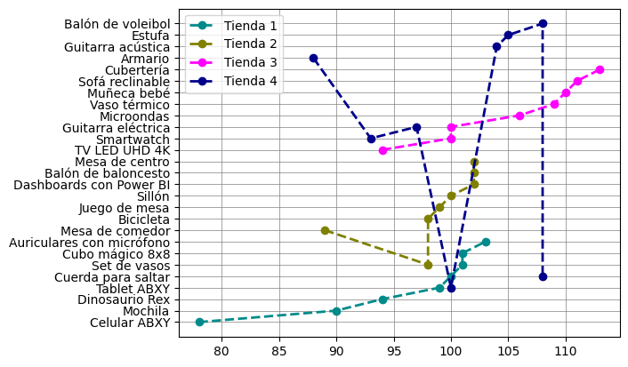

```python
#Definir ejes
x1, y1 = obtiene_ejes(producto_vendido, no_producto, False)
x2, y2 = obtiene_ejes(producto_vendido2, no_producto, False)
x3, y3 = obtiene_ejes(producto_vendido3, no_producto, False)
x4, y4 = obtiene_ejes(producto_vendido4, no_producto, False)

#Gráficas
plt.plot(y1, x1, 'o--', color = '#008B8B', scalex=bool, linewidth=2, label = 'Tienda 1')
plt.plot(y2, x2, 'o--', color = '#808000', scalex=bool, linewidth=2, label = 'Tienda 2')
plt.plot(y3, x3, 'o--', color = '#FF00FF', scalex=bool, linewidth=2, label = 'Tienda 3')
plt.plot(y4, x4, 'o--', color = '#00008B', scalex=bool, linewidth=2, label = 'Tienda 4')

#Estilo gráfica
plt.grid(color = 'gray', linestyle = '-', linewidth = 0.5)
plt.legend()

#Muestea gráfica
plt.show()
```

##### Costo de envío

```
[26018.6096, 25216.2357, 24805.6804, 23459.4572]
```

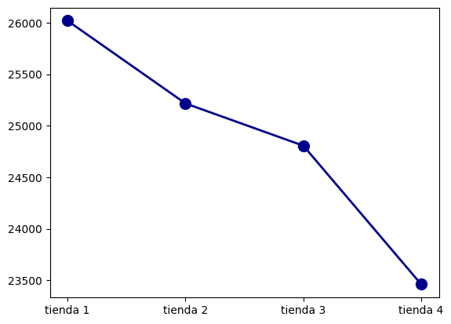

```python
#Costos de envio en tiendas
envio = [costo_envio_t,costo_envio_t2,costo_envio_t3,costo_envio_t4]
print(envio)
#Gráfica
plt.plot(negocio,envio, color = '#00008B', linewidth = 2, marker = 'o', ms = 10)
```

# Informe final y análisis de desempeño para la cadena Alura Store

Este informe analiza el desempeño de las cuatro tiendas de la cadena Alura Store a través de sus ingresos, ventas por categoría, productos más y menos vendidos, calificaciones de clientes y costos de envío. El objetivo es identificar cuál tienda presenta menor eficiencia para recomendar su venta e iniciar un nuevo emprendimiento.

## Análisis de facturación

Los ingresos generados por cada tienda son los siguientes:

- Tienda 1: $1,150,880,400.0 (mayor ingreso)
- Tienda 2: $1,116,343,500.0 (segunda mejor)
- Tienda 3: $1,098,019,600.0 (tercera)
- Tienda 4: $1,038,375,700.0 (menor ingreso)

La Tienda 4 presenta el ingreso más bajo, mientras que la Tienda 1 lidera en facturación.

## Ventas por categoría

La mayoría de las tiendas tienen como categoría más vendida **Muebles**, con excepción de la Tienda 2, que lidera en **Electrónicos**.

| Tienda | Categoría | Cantidad Vendida |
| --- | --- | --- |
| 1 | Muebles | 1446 |
| 2 | Electrónicos | 1333 |
| 3 | Muebles | 1408 |
| 4 | Muebles | 1392 |

Esto indica que, en general, los clientes prefieren comprar muebles, excepto en la Tienda 2 donde predominan los electrónicos.

## Satisfacción del cliente

Las calificaciones promedio otorgadas por los clientes son:

- Tienda 3: 4.0483 (mejor calificada)
- Tienda 2: 4.0373
- Tienda 4: 3.9958
- Tienda 1: 3.9767 (menor calificada)

La Tienda 3 es la preferida en satisfacción, mientras que la Tienda 1 obtiene la valoración más baja.

## Productos más y menos vendidos

Los productos más vendidos en cada tienda son:

- Tienda 1: Secadora de ropa (214 unidades)
- Tienda 2: Iniciando en programación (223 unidades)
- Tienda 3: Bicicleta (191 unidades)
- Tienda 4: Dashboards con Power BI (196 unidades)

Los productos menos vendidos son:

- Tienda 1: Celular ABXY (78 unidades)
- Tienda 2: Mesa de comedor (89 unidades)
- Tienda 3: TV LED UHD 4K (94 unidades)
- Tienda 4: Armario (88 unidades)

## Costo promedio de envío

El costo de envío promedio por tienda es:

- Tienda 4: $23,459.46 (más eficiente)
- Tienda 3: $24,805.68
- Tienda 2: $25,216.24
- Tienda 1: $26,018.61 (menos eficiente)

La Tienda 4 presenta el menor costo logístico, lo que podría mejorar su margen de ganancia a pesar de sus bajas ventas.